Florent Lombard← Enseignements

Enseignements › Master COAST › M1 › Télédétection

# Explorer les images satellitaires avec R

## Objectifs du tutoriel

À la fin de ce tutoriel, vous serez capable de :

- Organiser les données d’un projet et écrire un chemin d’accès permettant à R de retrouver un fichier.
- Importer des bandes spectrales avec `terra` et vérifier leur résolution, leur emprise et leur système de coordonnées.
- Assembler les bandes, sélectionner des couches et afficher des compositions en couleurs naturelles et en fausses couleurs.
- Découper une image avec `crop()`, la masquer avec `mask()` et comprendre la différence entre ces deux opérations.
- Créer des points étiquetés dans QGIS, extraire leurs valeurs spectrales dans R et calculer des signatures moyennes.
- Comparer les signatures spectrales de plusieurs catégories d’occupation du sol.

## Prérequis — Comprendre les chemins d’accès

Vous devez disposer de R, RStudio et QGIS, ainsi que des données téléchargeables ci-dessous. Le package `terra` sera chargé dans R. Avant d’importer une image, il faut savoir indiquer à R où elle se trouve sur votre ordinateur.

### Télécharger les données du tutoriel

[Télécharger les six bandes et la zone d’étude (ZIP, 63 Mo)](https://github.com/florentlombard/florentlombard.github.io/releases/download/donnees-coast-v1/donnees_camargue.zip)

Scène : `LC09_L2SP_196030_20240805_20240806_02_T1`. L’archive contient les six bandes B2 à B7 prêtes à être utilisées dans ce cours, ainsi que `camargue.gpkg`, dans le système de coordonnées de l’image.

Téléchargez l’archive, puis décompressez-la dans le dossier de votre projet RStudio. Vous obtenez `data/LC09_L2SP_196030_20240805_20240806_02_T1/`. Conservez les noms des fichiers : les chemins des blocs de code correspondent à cette organisation.

### 1. Un chemin d’accès est l’adresse d’un dossier ou d’un fichier

Un fichier possède un **nom** et se trouve dans un **dossier**. Ce dossier peut lui-même être situé dans un autre dossier. Le chemin décrit la succession des dossiers à parcourir pour atteindre le fichier.

```
data/LC09_L2SP_196030_20240805_20240806_02_T1/LC09_L2SP_196030_20240805_20240806_02_T1_REFL_B2.tif
```

Lisez cette adresse de gauche à droite : ouvrir le dossier `data`, puis le dossier `LC09_L2SP_196030_20240805_20240806_02_T1`, puis le fichier dont le nom se termine par `_B2.tif`. Le symbole `/` sépare les niveaux. `.tif` est l’extension du fichier ; elle fait partie de son nom.

**Un chemin de dossier et un chemin de fichier ne désignent pas la même chose.** `data/LC09_L2SP_196030_20240805_20240806_02_T1` désigne un dossier. Pour importer une bande, il faut ajouter son nom complet, extension comprise.

### 2. Créer un projet et organiser les données

1. Dans l’explorateur de fichiers de votre ordinateur, créez un dossier nommé `tutoriel_satellites`, par exemple dans Documents.
2. Dans RStudio, choisissez **File → New Project → Existing Directory**. Sélectionnez ce dossier, puis cliquez sur **Create Project**. RStudio y crée un fichier portant l’extension `.Rproj`.
3. Téléchargez l’archive à l’aide du bouton ci-dessus, puis décompressez-la dans le dossier du projet. Les fichiers doivent être réellement extraits : R ne les lit pas à l’intérieur du fichier ZIP avec les commandes utilisées ici.
4. Dans `tutoriel_satellites`, créez si nécessaire le dossier `data`, puis son sous-dossier `LC09_L2SP_196030_20240805_20240806_02_T1`. Placez les six fichiers `.tif` et la zone d’étude `camargue.gpkg` dans ce sous-dossier. Si l’extraction a déjà créé cette organisation, conservez-la sans ajouter un deuxième dossier `data`.
5. Pour reprendre le travail plus tard, ouvrez le fichier `.Rproj`. Enregistrez votre script R dans le dossier du projet.

| Élément | Emplacement attendu |
| --- | --- |
| Projet RStudio | `tutoriel_satellites/tutoriel_satellites.Rproj` |
| Script R | `tutoriel_satellites/exploration.R` |
| Dossier des données | `tutoriel_satellites/data/LC09_L2SP_196030_20240805_20240806_02_T1` |
| Bande B2 | `tutoriel_satellites/data/LC09_L2SP_196030_20240805_20240806_02_T1/LC09_L2SP_196030_20240805_20240806_02_T1_REFL_B2.tif` |
| Zone d’étude | `tutoriel_satellites/data/LC09_L2SP_196030_20240805_20240806_02_T1/camargue.gpkg` |

### 3. Identifier le point de départ : le dossier de travail

Pour interpréter un chemin relatif, R part de son **dossier de travail**. Exécutez cette commande dans la console :

```r
getwd()
```

Si votre projet est dans Documents sous Windows, le résultat peut par exemple être `"C:/Users/Lea/Documents/tutoriel_satellites"`. Votre résultat sera différent : il doit correspondre au dossier de votre projet.

Ouvrir le projet RStudio initialise normalement le dossier de travail à la racine de ce projet. **Ouvrir seulement un script ne garantit pas que R travaille dans le dossier du script.** Le lieu où vous enregistrez le HTML ne détermine pas non plus le dossier de travail de R.

```r
list.files()
```

Sans argument, `list.files()` affiche les noms présents dans le dossier de travail. Vous devez notamment y retrouver `data`. Cette commande affiche les noms ; elle ne change pas de dossier.

### 4. Distinguer chemin relatif et chemin absolu

| Type | Exemple | Point de départ |
| --- | --- | --- |
| Relatif | `data/LC09_L2SP_196030_20240805_20240806_02_T1/camargue.gpkg` | Le dossier affiché par `getwd()`. |
| Absolu sous Windows | `C:/Users/Lea/Documents/tutoriel_satellites/data/LC09_L2SP_196030_20240805_20240806_02_T1/camargue.gpkg` | La racine du disque `C:`. |
| Absolu sous macOS | `/Users/Lea/Documents/tutoriel_satellites/data/LC09_L2SP_196030_20240805_20240806_02_T1/camargue.gpkg` | La racine du système de fichiers, indiquée par le premier `/`. |

Le chemin relatif ne contient pas toute l’adresse depuis la racine : il indique le trajet depuis le dossier de travail. Si ce dossier est `tutoriel_satellites`, écrivez `data/LC09_L2SP_196030_20240805_20240806_02_T1`, sans répéter `tutoriel_satellites`. Si le dossier de travail change, le même chemin relatif peut ne plus retrouver les données.

Le chemin absolu désigne un emplacement complet indépendamment du dossier de travail. Les exemples avec `Lea` sont fictifs : adaptez-les à votre ordinateur. Pour ce cours, utilisez les chemins relatifs depuis le projet. Vous pourrez ainsi déplacer le dossier du projet avec ses données sans réécrire tous les chemins.

### 5. Écrire correctement le chemin dans R

- **Entourez le chemin de guillemets.** C’est du texte : `"data/LC09_L2SP_196030_20240805_20240806_02_T1"`. Sans guillemets, R essaie d’interpréter ce que vous écrivez comme du code.
- **Utilisez des barres obliques `/`, y compris sous Windows.** Un chemin copié depuis l’explorateur Windows peut contenir des `\`. Dans une chaîne R, une barre inverse introduit une séquence spéciale : remplacez-les par `/`. Par exemple, écrivez `"C:/Users/Lea/Documents"`.
- **Recopiez le nom exact.** Vérifiez les lettres, les chiffres, les espaces et l’extension. Respectez les majuscules et minuscules pour que votre script reste utilisable sur différents systèmes.
- **Les espaces sont autorisés entre guillemets.** `"data/mon dossier/image.tif"` est un chemin valide si ces dossiers et ce fichier existent.

Vous pouvez construire un chemin à partir de ses différentes parties avec `file.path()` :

```r
file.path("data", "camargue", "camargue.gpkg")
```

Cette commande fabrique une adresse ; elle ne crée pas le fichier et ne vérifie pas son existence.

### 6. Vérifier avant d’importer

Exécutez ces commandes une par une. Elles vérifient successivement le point de départ, le dossier des données, son contenu et un fichier précis.

```r
getwd()
dir.exists("data/LC09_L2SP_196030_20240805_20240806_02_T1")
list.files("data/LC09_L2SP_196030_20240805_20240806_02_T1")
file.exists("data/LC09_L2SP_196030_20240805_20240806_02_T1/camargue.gpkg")
file.exists("data/LC09_L2SP_196030_20240805_20240806_02_T1/LC09_L2SP_196030_20240805_20240806_02_T1_REFL_B2.tif")
```

`TRUE` signifie que le dossier ou le fichier a été trouvé à cette adresse ; `FALSE` signifie qu’il n’a pas été trouvé. `list.files()` doit afficher les noms des six bandes et de la zone d’étude. Un résultat `character(0)` ne suffit pas à conclure que le dossier est vide : vérifiez d’abord son existence avec `dir.exists()`.

### 7. Comprendre et corriger les erreurs courantes

[output not shown]

Si vous devez sélectionner un fichier pour repérer son adresse, exécutez `file.choose()` dans la console, puis choisissez le fichier dans la fenêtre. R renvoie son chemin absolu. Comparez cette adresse à l’organisation prévue du projet pour comprendre où se situe l’écart.

## Chapitre 1 — Importer, explorer et préparer l’image

Importer les bandes, comprendre la grille raster, explorer les compositions colorées et préparer l’image multibande.

### 1.1 Préparer le projet

**Objectif :** Organiser les fichiers et charger les outils spatiaux.

```r
library(terra)
list.files("data/LC09_L2SP_196030_20240805_20240806_02_T1")
```

```
[1] "camargue.gpkg"
[2] "LC09_L2SP_196030_20240805_20240806_02_T1_REFL_B2.tif"
[3] "LC09_L2SP_196030_20240805_20240806_02_T1_REFL_B3.tif"
[4] "LC09_L2SP_196030_20240805_20240806_02_T1_REFL_B4.tif"
[5] "LC09_L2SP_196030_20240805_20240806_02_T1_REFL_B5.tif"
[6] "LC09_L2SP_196030_20240805_20240806_02_T1_REFL_B6.tif"
[7] "LC09_L2SP_196030_20240805_20240806_02_T1_REFL_B7.tif"
```

Utilisez le projet et l’organisation des dossiers préparés dans les prérequis. Si les noms attendus ne s’affichent pas, revenez à la section Vérifier avant d’importer avant de poursuivre.

Les données sont un extrait rectangulaire de la scène Landsat 9 du 5 août 2024. Elles ont été découpées avant leur distribution, avec une marge d’environ 3 km autour du rectangle englobant la zone d’étude. Leur résolution reste de 30 m : aucun rééchantillonnage n’a été effectué. Dans le cours, « image originale » désigne cet extrait fourni. Il dépasse le polygone pour permettre de comparer les effets de `crop()` et `mask()`. Les figures affichent cet extrait, sans masque supplémentaire des nuages.

Les valeurs des fichiers fournis représentent des réflectances de surface, sans unité. Par exemple, 0,20 correspond à 20 % dans cette représentation. Les graphiques du cours utilisent les valeurs décimales.

Une couche polygonale `camargue.gpkg` est fournie dans le système de coordonnées de l’image. Il s’agit d’une copie reprojetée de la zone transmise par l’enseignant.

### 1.2 Importer les six bandes spectrales

**Objectif :** Créer un objet pour chacune des bandes B2 à B7.

```r
b2 <- rast("data/LC09_L2SP_196030_20240805_20240806_02_T1/LC09_L2SP_196030_20240805_20240806_02_T1_REFL_B2.tif")
b3 <- rast("data/LC09_L2SP_196030_20240805_20240806_02_T1/LC09_L2SP_196030_20240805_20240806_02_T1_REFL_B3.tif")
b4 <- rast("data/LC09_L2SP_196030_20240805_20240806_02_T1/LC09_L2SP_196030_20240805_20240806_02_T1_REFL_B4.tif")
b5 <- rast("data/LC09_L2SP_196030_20240805_20240806_02_T1/LC09_L2SP_196030_20240805_20240806_02_T1_REFL_B5.tif")
b6 <- rast("data/LC09_L2SP_196030_20240805_20240806_02_T1/LC09_L2SP_196030_20240805_20240806_02_T1_REFL_B6.tif")
b7 <- rast("data/LC09_L2SP_196030_20240805_20240806_02_T1/LC09_L2SP_196030_20240805_20240806_02_T1_REFL_B7.tif")
b2
```

```
class       : SpatRaster
dimensions  : 1660, 3403, 1  (nrow, ncol, nlyr)
resolution  : 30, 30  (x, y)
extent      : 557985, 660075, 4783005, 4832805  (xmin, xmax, ymin, ymax)
coord. ref. : WGS 84 / UTM zone 31N (EPSG:32631)
source      : LC09_L2SP_196030_20240805_20240806_02_T1_REFL_B2.tif
name        :       Blue
```

#### Fonctions, arguments et affectation

Une fonction réalise une opération ; ses arguments sont écrits entre parenthèses. `rast("chemin")` ouvre ici un raster. Les guillemets indiquent une chaîne de caractères et non un objet nommé `data`. Le symbole `<-` affecte le résultat à un nom : R évalue d’abord ce qui est à droite, puis associe le résultat au nom situé à gauche.

`b2` est un nom choisi par l’utilisateur, pas une instruction imposée par Landsat. R distingue les majuscules des minuscules : `b2` et `B2` seraient deux objets différents. Le texte précédé de `#` est un commentaire et n’est pas exécuté.

`rast()` crée un **SpatRaster**. Pour un fichier, terra lit sa description et peut lire les valeurs depuis le disque lorsque le traitement l’exige. Créer l’objet ne signifie donc pas que toute l’image a été copiée dans la mémoire de R.

#### Lire le résultat affiché

Écrire `b2` seul affiche un résumé : classe de l’objet, dimensions, résolution, emprise, système de coordonnées, fichier source et nom de couche. Ce résumé n’est pas une carte. Une cellule correspond à une position de la grille ; sa valeur représente ici une mesure spectrale. Les fichiers REFL distribués pour ce cours contiennent des réflectances de surface préparées ; cette hypothèse ne doit pas être appliquée automatiquement aux fichiers originaux d’autres produits satellitaires.

| Nom complet du fichier sur le disque | Domaine spectral | Objet créé dans R |
| --- | --- | --- |
| `LC09_L2SP_196030_20240805_20240806_02_T1_REFL_B2.tif` | Bleu | `b2` |
| `LC09_L2SP_196030_20240805_20240806_02_T1_REFL_B3.tif` | Vert | `b3` |
| `LC09_L2SP_196030_20240805_20240806_02_T1_REFL_B4.tif` | Rouge | `b4` |
| `LC09_L2SP_196030_20240805_20240806_02_T1_REFL_B5.tif` | Proche infrarouge | `b5` |
| `LC09_L2SP_196030_20240805_20240806_02_T1_REFL_B6.tif` | Infrarouge à ondes courtes 1 | `b6` |
| `LC09_L2SP_196030_20240805_20240806_02_T1_REFL_B7.tif` | Infrarouge à ondes courtes 2 | `b7` |

Dans `b2 <- rast("data/LC09_L2SP_196030_20240805_20240806_02_T1/LC09_L2SP_196030_20240805_20240806_02_T1_REFL_B2.tif")`, le texte entre guillemets indique le chemin du fichier à lire. `rast()` crée un objet raster à partir de ce fichier ; `<-` affecte cet objet au nom `b2` dans la session R. Le nom du fichier et le nom de l’objet sont donc deux choses distinctes.

Le nom `b2` est choisi par la personne qui écrit le code. On pourrait écrire `bleu <- rast("data/LC09_L2SP_196030_20240805_20240806_02_T1/LC09_L2SP_196030_20240805_20240806_02_T1_REFL_B2.tif")` pour lire le même fichier dans un objet nommé `bleu`. Pour utiliser ensuite cet objet, on écrit `plot(bleu)`, sans guillemets. Cette affectation ne renomme pas le fichier sur le disque.

Les numéros des bandes dépendent du capteur : cette correspondance concerne Landsat 9.

### 1.3 Examiner la géométrie du raster

**Objectif :** Comprendre où se situe la grille et comment elle est organisée avant de comparer les pixels.

```r
crs(b2, describe = TRUE)
```

```
                   name authority  code
1 WGS 84 / UTM zone 31N      EPSG 32631
                                                                                                                                                                                                                                                                                                   area
1 Between 0°E and 6°E, northern hemisphere between equator and 84°N, onshore and offshore. Algeria. Andorra. Belgium. Benin. Burkina Faso. Denmark - North Sea. France. Germany - North Sea. Ghana. Luxembourg. Mali. Netherlands. Niger. Nigeria. Norway. Spain. Togo. United Kingdom (UK) - North Sea
       extent
1 0, 6, 84, 0
```

```r
ncell(b2)
```

```
[1] 5648980
```

```r
dim(b2)
```

```
[1] 1660 3403    1
```

```r
res(b2)
```

```
[1] 30 30
```

```r
nlyr(b2)
```

```
[1] 1
```

```r
compareGeom(b2, b3)
```

```
[1] TRUE
```

#### Le rôle de chaque fonction

`crs()` consulte le système de référence des coordonnées. Sans argument supplémentaire, `crs(b2)` renvoie sa description détaillée ; `describe = TRUE` en propose un résumé. Le CRS donne le sens des coordonnées et leurs unités. Une résolution de 30 dans un système métrique représente 30 mètres ; la même valeur dans un système en degrés aurait une autre signification.

`ncell()` compte les cellules de la grille, soit le nombre de lignes multiplié par le nombre de colonnes. `dim()` renvoie un vecteur de trois nombres : lignes, colonnes, couches. `res()` renvoie les dimensions d’une cellule dans les directions x et y. `nlyr()` compte les couches. Avec plusieurs bandes, `ncell()` ne multiplie pas le nombre de positions spatiales par le nombre de bandes.

`compareGeom()` vérifie par défaut la compatibilité des grilles : CRS, emprise et dimensions ; la résolution et l’alignement en découlent pour cette grille régulière. On peut aussi demander explicitement certaines vérifications avec ses arguments. Un résultat `TRUE` signifie que les grilles sont compatibles selon les critères testés, **pas que les valeurs des pixels sont identiques**. En cas d’incompatibilité, la fonction peut arrêter le traitement avec une erreur ; `stopOnError = FALSE` permet d’obtenir une valeur logique.

#### Pourquoi vérifier avant de calculer ?

Un calcul pixel par pixel suppose que les cellules comparées correspondent aux mêmes lieux. Deux images prises sur le même territoire peuvent avoir des grilles décalées. Le CRS commun est nécessaire, mais il ne suffit pas à lui seul : emprise, taille des cellules et alignement doivent aussi être compatibles.

### 1.4 Assembler plusieurs bandes

**Objectif :** Construire un objet à plusieurs couches en conservant leur ordre.

```r
s <- c(b5, b4, b3)
s
```

```
class       : SpatRaster
dimensions  : 1660, 3403, 3  (nrow, ncol, nlyr)
resolution  : 30, 30  (x, y)
extent      : 557985, 660075, 4783005, 4832805  (xmin, xmax, ymin, ymax)
coord. ref. : WGS 84 / UTM zone 31N (EPSG:32631)
sources     : LC09_L2SP_196030_20240805_20240806_02_T1_REFL_B5.tif
              LC09_L2SP_196030_20240805_20240806_02_T1_REFL_B4.tif
              LC09_L2SP_196030_20240805_20240806_02_T1_REFL_B3.tif
names       :        NIR,        Red,     Green
```

```r
nlyr(s)
```

```
[1] 3
```

`c()` sert habituellement à combiner des éléments dans un vecteur. R adapte cependant le comportement de certaines fonctions à la classe de leurs arguments. Appliqué à des `SpatRaster`, `c()` assemble les couches dans un seul objet raster.

L’ordre est celui des arguments : la couche 1 de `s` est le NIR, la couche 2 le rouge, la couche 3 le vert. `s` n’est ni une moyenne ni une fusion arithmétique des bandes : chaque valeur spectrale reste dans sa couche. Le nombre de positions spatiales reste inchangé, tandis que `nlyr(s)` vaut 3.

Cette organisation permet de conserver plusieurs mesures pour un même pixel. Elle sera essentielle pour les compositions colorées, les indices spectraux et les classifications.

### 1.5 Assembler les six fichiers en une image

**Objectif :** Construire un vecteur de chemins puis un objet multibande.

```r
filenames <- paste0("data/LC09_L2SP_196030_20240805_20240806_02_T1/LC09_L2SP_196030_20240805_20240806_02_T1_REFL_B", 2:7, ".tif")
filenames
```

```
[1] "data/LC09_L2SP_196030_20240805_20240806_02_T1/LC09_L2SP_196030_20240805_20240806_02_T1_REFL_B2.tif"
[2] "data/LC09_L2SP_196030_20240805_20240806_02_T1/LC09_L2SP_196030_20240805_20240806_02_T1_REFL_B3.tif"
[3] "data/LC09_L2SP_196030_20240805_20240806_02_T1/LC09_L2SP_196030_20240805_20240806_02_T1_REFL_B4.tif"
[4] "data/LC09_L2SP_196030_20240805_20240806_02_T1/LC09_L2SP_196030_20240805_20240806_02_T1_REFL_B5.tif"
[5] "data/LC09_L2SP_196030_20240805_20240806_02_T1/LC09_L2SP_196030_20240805_20240806_02_T1_REFL_B6.tif"
[6] "data/LC09_L2SP_196030_20240805_20240806_02_T1/LC09_L2SP_196030_20240805_20240806_02_T1_REFL_B7.tif"
```

```r
image <- rast(filenames)
nlyr(image)
```

```
[1] 6
```

`2:7` produit la suite entière 2, 3, 4, 5, 6, 7. `paste0()` assemble le préfixe, chaque numéro puis le suffixe `.tif`, sans ajouter de séparateur. Le préfixe et le suffixe sont réutilisés pour chaque numéro : R réalise une opération vectorisée grâce au recyclage des éléments de longueur 1.

`filenames` est un **vecteur de caractères**, pas une liste au sens technique de R. `rast(filenames)` ouvre les six fichiers et assemble leurs couches dans l’ordre des chemins. Ce n’est ni une moyenne ni une fusion des mesures.

**La position d’une couche n’est pas le numéro de la bande Landsat.** B2 occupe ici la position 1, B3 la position 2, B4 la position 3, B5 la position 4, B6 la position 5 et B7 la position 6. Cette distinction évite une erreur classique dans les compositions colorées.

| Position dans image | Bande Landsat | Domaine spectral |
| --- | --- | --- |
| 1 | B2 | Bleu |
| 2 | B3 | Vert |
| 3 | B4 | Rouge |
| 4 | B5 | NIR |
| 5 | B6 | SWIR1 |
| 6 | B7 | SWIR2 |

Les six fichiers ont la même grille, nécessaire pour les assembler et effectuer des calculs pixel par pixel.

### 1.6 Afficher les bandes en niveaux de gris

**Objectif :** Comparer la distribution spatiale des valeurs dans quatre domaines spectraux.

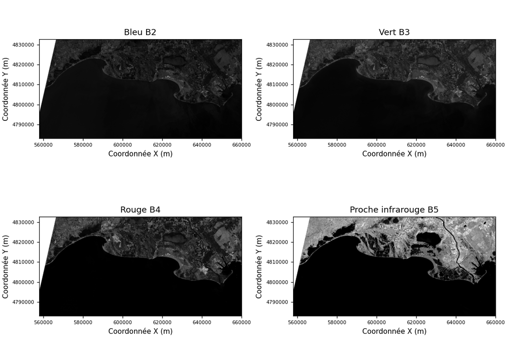

Image fournie : bandes bleu, vert, rouge et proche infrarouge

```r
par(mfrow = c(2, 2))
plot(b2, main = "Bleu", col = gray(0:100 / 100))
plot(b3, main = "Vert", col = gray(0:100 / 100))
plot(b4, main = "Rouge", col = gray(0:100 / 100))
plot(b5, main = "Proche infrarouge", col = gray(0:100 / 100))
```

```r
par(mfrow = c(1, 1))
```

`par()` règle les paramètres du dispositif graphique. `mfrow = c(2, 2)` partage la figure en deux lignes et deux colonnes, remplies par lignes. Le dernier appel revient à une figure unique pour les graphiques suivants.

`plot()` reconnaît un `SpatRaster` et dessine sa grille. `main` fournit le titre. `col` reçoit une palette : `0:100 / 100` crée 101 nombres entre 0 et 1 et `gray()` transforme ces nombres en couleurs, du noir au blanc.

Les cellules claires ont les valeurs élevées dans la palette choisie. Une surface peut être sombre dans le rouge et claire dans le NIR : la luminosité dépend de la bande. La végétation vivante présente souvent ce contraste, tandis que l’eau absorbe fortement le proche infrarouge.

**Attention à la comparaison** : chaque carte peut utiliser sa propre plage de valeurs. Deux gris identiques sur deux panneaux ne représentent donc pas nécessairement la même réflectance. Consultez les légendes avant de comparer quantitativement les cartes. Une carte claire n’indique pas à elle seule une valeur élevée dans toutes les bandes.

### 1.7 Produire une composition en couleurs naturelles

**Objectif :** Associer les bandes rouge, verte et bleue aux trois canaux de l’écran.

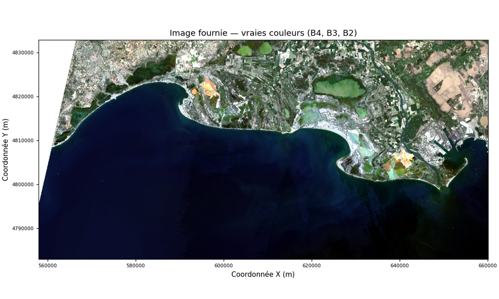

Image fournie en vraies couleurs : B4, B3, B2

```r
landsatRGB <- c(b4, b3, b2)
plotRGB(landsatRGB, stretch = "lin")
```

Un écran représente une couleur en combinant trois canaux : rouge, vert et bleu. Dans `plotRGB()`, les positions 1, 2 et 3 sont utilisées par défaut pour ces canaux. Avec `c(b4, b3, b2)`, la mesure dans le rouge alimente donc le rouge de l’écran, celle du vert le vert et celle du bleu le bleu.

`stretch = "lin"` améliore le contraste de l’affichage avec un étirement linéaire ; terra utilise par défaut des quantiles de 2 % et 98 % pour ce réglage. Il ne transforme pas les valeurs enregistrées dans `landsatRGB`. Il faut distinguer le calcul sur les données et leur représentation à l’écran.

La composition est dite en couleurs naturelles parce que les canaux correspondent aux domaines visibles mesurés. Elle ne reproduit pas exactement la vision humaine : capteur, traitement et contraste influencent son apparence. Les pixels affichés peuvent aussi être réduits en nombre pour dessiner rapidement une grande image.

### 1.8 Produire une composition en fausses couleurs

**Objectif :** Rendre visible le contraste du proche infrarouge avec les bandes visibles.

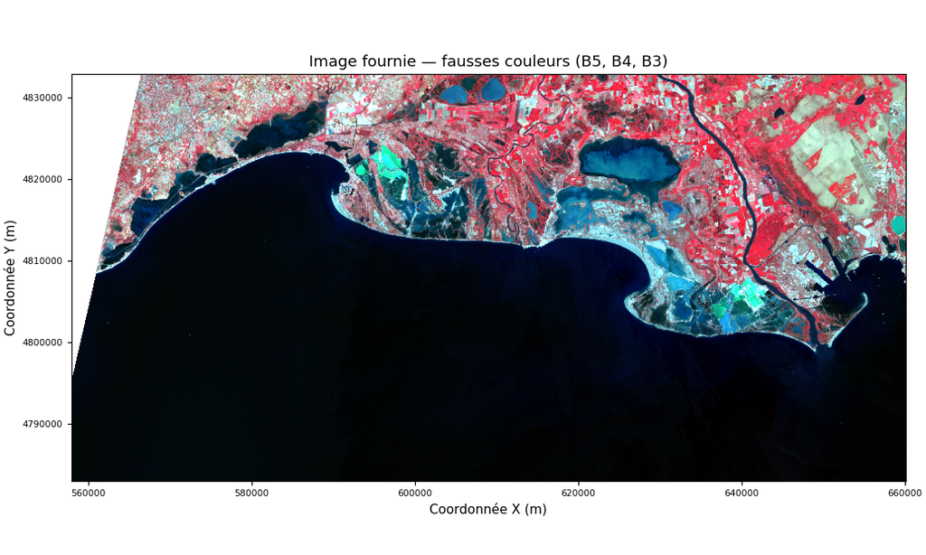

Image fournie en fausses couleurs : B5, B4, B3

```r
landsatFCC <- c(b5, b4, b3)
plotRGB(landsatFCC, stretch = "lin")
```

La bande NIR occupe maintenant la première position et alimente le canal rouge. Le rouge spectral alimente le canal vert et le vert spectral le canal bleu. Les noms des canaux d’écran ne désignent donc plus les domaines spectraux mesurés.

Une végétation qui réfléchit fortement le NIR apparaît souvent rouge. L’eau, généralement peu réfléchissante dans le NIR, est souvent sombre. Ces tendances aident à interpréter l’image mais ne constituent pas des règles de classification infaillibles : turbidité, ombres, sols, humidité et état de la végétation peuvent modifier les réponses.

**Comparer les deux figures** permet de repérer les mêmes structures spatiales avec deux traductions colorées. La géométrie n’a pas changé ; c’est l’affectation des bandes aux canaux qui a changé. Une fausse couleur ne représente pas un traitement incorrect : c’est un outil d’interprétation.

### 1.9 Sélectionner des couches

**Objectif :** Comprendre l’indexation et distinguer l’objet original de ses sous-ensembles.

```r
imagesub1 <- subset(image, 1:3)
imagesub2 <- image[[1:3]]
nlyr(image)
```

```
[1] 6
```

```r
nlyr(imagesub1)
```

```
[1] 3
```

```r
nlyr(imagesub2)
```

```
[1] 3
```

`subset(image, 1:3)` sélectionne les couches aux positions 1, 2 et 3. La sélection `image[[1:3]]` fait la même chose pour un `SpatRaster`.

Ces positions concernent l’ordre courant de l’objet. Ici, elles représentent B2, B3 et B4. Ce sont les trois bandes visibles, mais leur ordre bleu–vert–rouge n’est pas celui des canaux d’écran rouge–vert–bleu d’une composition naturelle.

Les résultats sont affectés à de nouveaux noms. `image` conserve ses six couches. Une affectation à un autre objet ne modifie pas automatiquement l’original. R distingue aussi les majuscules des minuscules : `image` et `Image` seraient deux noms différents.

### 1.10 Nommer les couches

**Objectif :** Identifier les domaines spectraux par des noms explicites.

```r
names(image)
```

```
[1] "Blue"  "Green" "Red"   "NIR"   "SWIR1" "SWIR2"
```

```r
names(image) <- c("Blue", "Green", "Red", "NIR", "SWIR1", "SWIR2")
names(image)
```

```
[1] "Blue"  "Green" "Red"   "NIR"   "SWIR1" "SWIR2"
```

```r
image[["NIR"]]
```

```
class       : SpatRaster
dimensions  : 1660, 3403, 1  (nrow, ncol, nlyr)
resolution  : 30, 30  (x, y)
extent      : 557985, 660075, 4783005, 4832805  (xmin, xmax, ymin, ymax)
coord. ref. : WGS 84 / UTM zone 31N (EPSG:32631)
source      : LC09_L2SP_196030_20240805_20240806_02_T1_REFL_B5.tif
name        :        NIR
```

`names(image)` consulte les noms des couches. La forme `names(image) <- ...` les remplace : c’est une affectation à une propriété de l’objet. Il faut fournir autant de noms que de couches, dans le même ordre. Renommer une couche ne change ni ses valeurs ni sa position.

`c("Blue", "Green", "Red", "NIR", "SWIR1", "SWIR2")` construit un vecteur de caractères. Les guillemets distinguent ces textes des noms d’objets R. La sélection `image[["NIR"]]` utilise ensuite le nom de la couche plutôt que sa position. Il faut respecter exactement la casse.

B6 et B7 mesurent l’infrarouge à ondes courtes. Ces domaines complètent les bandes visibles et le NIR pour étudier les réponses spectrales des surfaces. Les noms utilisés ici seront aussi les colonnes du tableau de valeurs extraites.

## Chapitre 2 — Interaction vecteur-raster

Importer une zone vectorielle, la superposer à l’image, découper le raster avec crop(), puis appliquer mask() et exporter le résultat.

### 2.1 Afficher, découper et masquer : trois étapes

Nous conservons la même bande rouge et la même échelle de couleurs pour observer les effets du traitement. La zone d’étude doit avoir le même système de projection que l’image.

#### 1. Afficher l’image originale

```r
zone <- vect("data/LC09_L2SP_196030_20240805_20240806_02_T1/camargue.gpkg", layer = "camargue")
plot(image[["Red"]], main = "Image originale", range = c(0, 0.5))
plot(zone, add = TRUE, border = "red", lwd = 2)
```

`plot()` affiche ici une seule couche, sélectionnée par son nom avec [["Red"]]. L’image originale est celle fournie pour ce cours. plot(zone, add = TRUE) ajoute le contour de la zone à la carte existante : afficher un contour ne modifie aucun pixel.

#### 2. Découper avec crop()

```r
imagecrop <- crop(image, zone)
plot(imagecrop[["Red"]], main = "Après crop()", range = c(0, 0.5))
plot(zone, add = TRUE, border = "red", lwd = 2)
```

crop() conserve le rectangle qui englobe le polygone. Le résultat est enregistré dans imagecrop : image reste disponible. La résolution et les valeurs des cellules conservées ne changent pas. Les cellules du rectangle situées hors du polygone sont encore présentes.

#### 3. Masquer avec mask()

```r
imagezone <- mask(imagecrop, zone)
plot(imagezone[["Red"]], main = "Après mask()", range = c(0, 0.5))
plot(zone, add = TRUE, border = "red", lwd = 2)
```

mask() remplace par NA les valeurs des cellules hors de la zone. NA signifie une valeur absente, et non zéro. L’emprise rectangulaire reste celle de imagecrop, mais seules les cellules du polygone restent visibles. Par défaut, les cellules touchant la limite peuvent être conservées.

#### Les trois vues côte à côte dans R

```r
par(mfrow = c(1, 3))
plot(image[["Red"]], main = "1. Image originale", range = c(0, 0.5))
plot(zone, add = TRUE, border = "red")
plot(imagecrop[["Red"]], main = "2. Après crop()", range = c(0, 0.5))
plot(zone, add = TRUE, border = "red")
plot(imagezone[["Red"]], main = "3. Après mask()", range = c(0, 0.5))
plot(zone, add = TRUE, border = "red")
par(mfrow = c(1, 1))
```

par(mfrow = c(1, 3)) dispose les figures sur une ligne. range = c(0, 0.5) impose la même échelle de couleurs. Les cartes ajustent leur cadrage à l’emprise de chaque objet ; crop() ne crée donc pas des pixels plus fins. Le dernier par() rétablit une seule figure.

#### Les trois résultats à partir des données Landsat

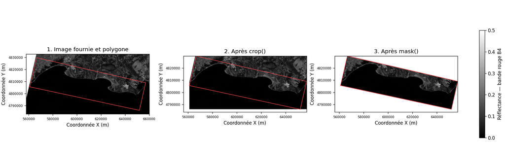

Landsat 9, 5 août 2024, bande rouge B4. Même échelle de réflectance dans les trois panneaux ; contour de la zone en rouge.

La première carte montre l’image rectangulaire fournie. La deuxième conserve le rectangle englobant le polygone : les cellules hors du contour rouge sont encore présentes. La troisième masque ces cellules : elles apparaissent en blanc. La grille de mesure reste à 30 m ; les cartes sont sous-échantillonnées pour leur affichage. Cette illustration utilise la bande de réflectance de surface du catalogue, sans masque supplémentaire des nuages.

#### Afficher la composition colorée après le masque

Nous utilisons maintenant `imagezone`, l’image obtenue après `crop()` puis `mask()`, à la place de l’image originale. L’ordre des six bandes reste identique.

```r
plotRGB(imagezone, r = 3, g = 2, b = 1, stretch = "lin")
```

La couche 3 (Red) alimente le canal rouge, la couche 2 (Green) le canal vert et la couche 1 (Blue) le canal bleu : il s’agit de la même composition en vraies couleurs qu’au chapitre 1, appliquée à la zone masquée. Les cellules hors du polygone sont absentes de l’affichage.

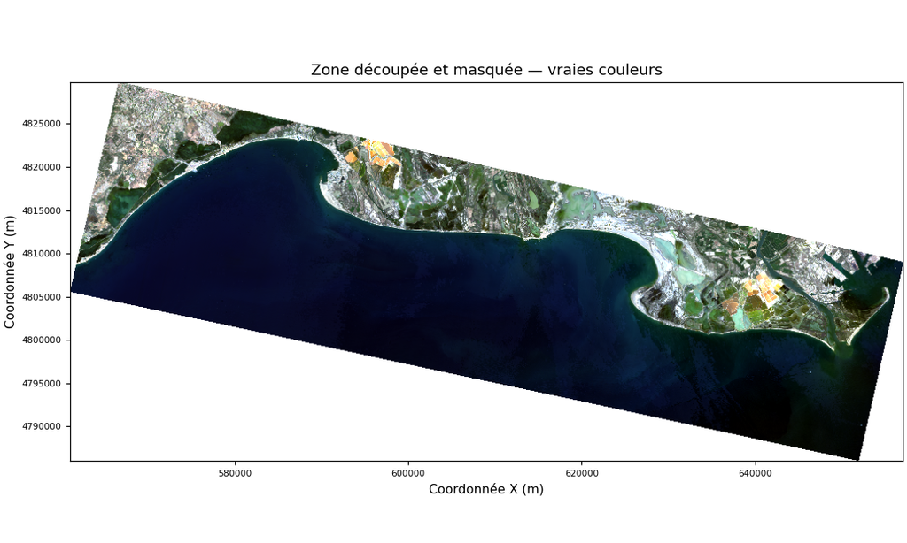

Composition en vraies couleurs après crop() et mask() : B4, B3, B2

### 2.2 Exporter le raster découpé

**Objectif :** Distinguer un objet en mémoire d’un fichier réutilisable sur le disque.

```r
writeRaster(imagezone, filename = "camargue_reflectance.tif", overwrite = TRUE)
file.exists("camargue_reflectance.tif")
```

```
[1] TRUE
```

`writeRaster()` écrit les valeurs et la géométrie dans un fichier. Le premier argument est le raster à exporter ; `filename` indique le chemin. L’extension `.tif` correspond ici au format GeoTIFF, qui peut être ouvert dans R ou dans un SIG.

`overwrite = TRUE` autorise le remplacement d’un fichier portant déjà ce nom. Choisissez donc ce nom consciemment. `FALSE`, ou l’absence d’autorisation de remplacement, permet d’éviter un écrasement involontaire.

Le chemin est relatif : le fichier sera créé dans le dossier de travail du traitement. Contrairement à `imagezone <- ...`, cette instruction écrit effectivement une donnée sur le disque. `file.exists()` vérifie sa présence, mais ne constitue pas une validation complète de ses valeurs.

Le fichier exporté contient les six couches retenues. Pour le relire dans une nouvelle session : `rast("camargue_reflectance.tif")`. Les variables R ne sont pas automatiquement restaurées quand on ouvre un fichier : il faut lui attribuer un nom.

## Chapitre 3 — Construire et interpréter les signatures

Créer des points de référence, extraire les valeurs des six bandes, puis comparer les signatures moyennes.

### 3.1 Utiliser les points fournis pour explorer les signatures

Un jeu de **60 points** vous est fourni pour vous entraîner à extraire les valeurs des six bandes et à comparer les signatures spectrales. Chaque point possède un identifiant, un code de catégorie et un libellé. L’exemple comprend cinq catégories, avec 12 points par catégorie.

| Code dans classe | Libellé | Nombre de points |
| --- | --- | --- |
| 1 | `eau` | 12 |
| 2 | `vegetation` | 12 |
| 3 | `sol_nu` | 12 |
| 4 | `bati` | 12 |
| 5 | `cultures` | 12 |

Télécharger les points de l’exemple. Placez `points_exemple.geojson` dans le dossier de votre projet RStudio, au même niveau que le fichier `.Rproj`. Les points sont également inclus dans l’archive du cours.

Les catégories servent à illustrer la méthode. En observant les points sur l’image, vous pourrez discuter la correspondance entre leur étiquette et la surface visible ; ce jeu d’exemple ne constitue pas une validation de terrain.

#### Suggestion : observer le jeu de points dans QGIS

Avant de créer vos propres points, vous pouvez ouvrir cet exemple dans QGIS pour comprendre comment le jeu de données est organisé.

1. Ajoutez `camargue_reflectance.tif`, exporté au chapitre 2, dans QGIS par glisser-déposer. Dans **Propriétés → Symbologie**, choisissez **Couleur à bandes multiples**, puis les bandes **3, 2, 1** pour les canaux rouge, vert, bleu. Vous pouvez aussi essayer **4, 3, 2** pour une composition en fausses couleurs.
2. Ajoutez `points_exemple.geojson` par glisser-déposer. Placez cette couche **au-dessus du raster** dans le panneau des couches pour voir les points sur l’image.
3. Faites un clic droit sur la couche de points, puis choisissez **Ouvrir la table attributaire**. Chaque ligne correspond à un point. `id` identifie le point ; `classe` indique sa catégorie ; `libelle` donne le nom de cette catégorie. Plusieurs points ont la même classe, mais chacun a un identifiant différent.
4. Dans **Propriétés → Symbologie** de la couche de points, choisissez **Catégorisé**, sélectionnez le champ `libelle`, puis cliquez sur **Classer** et **Appliquer**. Chaque catégorie apparaît avec une couleur différente.
5. Sélectionnez une ligne dans la table et utilisez **Zoomer sur les entités sélectionnées** pour retrouver le point sur l’image. Observez la surface sous le point et comparez-la à son libellé. Répétez avec plusieurs catégories.

Vous pouvez ensuite revenir dans R pour utiliser ces points. La section suivante vous guidera dans la création d’un jeu de points ayant la même structure.

#### Afficher les points sur la composition colorée

```r
pts_exemple <- vect("points_exemple.geojson")
plotRGB(imagezone, r = 3, g = 2, b = 1, stretch = "lin")
couleurs <- c("#1479b8", "#278044", "#ba8848", "#b62c47", "#9755a0")
points(pts_exemple, pch = 21, bg = couleurs[pts_exemple$classe],
       col = "white", cex = 1.2)
legend("bottomleft", legend = c("Eau", "Vegetation", "Sol nu", "Bati", "Cultures"),
       pch = 21, pt.bg = couleurs, col = "white", bty = "n")
```

`vect()` lit les points fournis. Dans `couleurs[pts_exemple$classe]`, chaque code de classe sélectionne une couleur. `points()` ajoute les positions à la composition déjà affichée ; `pch = 21` permet de distinguer le remplissage (`bg`) du contour (`col`).

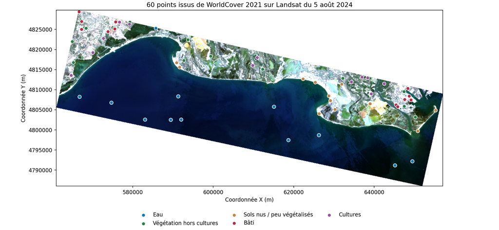

Localisation des 60 points sur la composition en vraies couleurs de la zone masquée.

#### Extraire les valeurs et calculer les signatures moyennes

```r
df_exemple <- extract(imagezone, pts_exemple)
df_exemple$classe <- pts_exemple$classe
df_exemple$libelle <- pts_exemple$libelle
bandes <- c("Blue", "Green", "Red", "NIR", "SWIR1", "SWIR2")
moyennes <- aggregate(df_exemple[, bandes],
                      by = list(libelle = df_exemple$libelle),
                      FUN = mean, na.rm = TRUE)
moyennes
```

`extract()` renvoie les valeurs des six bandes au point demandé. On ajoute la classe et son libellé aux lignes correspondantes. `aggregate()` rassemble les points par libellé et calcule la moyenne de chaque bande. Le CSV fourni contient aussi les valeurs extraites, pour consulter les résultats sans refaire l’extraction.

#### Signatures de l’exemple

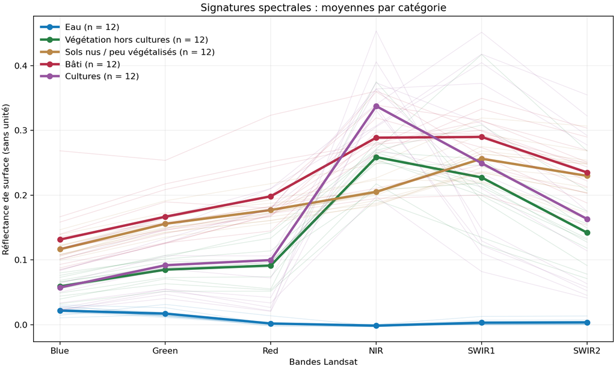

Traits épais : moyenne des 12 points de chaque catégorie. Traits fins : signatures individuelles. Les valeurs sont extraites des six bandes Landsat aux positions des points fournis.

Chaque courbe suit les valeurs d’une catégorie de Blue à SWIR2. Dans cet exemple, l’eau présente de faibles valeurs dans le NIR et les SWIR ; la végétation et les cultures présentent une hausse entre le rouge et le NIR. Les couleurs des courbes correspondent à celles des points sur la carte.

Télécharger les points · Télécharger les valeurs des six bandes

La section suivante explique comment créer et étiqueter vos propres points dans QGIS, après avoir observé la structure du jeu fourni. Vous pourrez ensuite appliquer la même extraction et comparer vos signatures à cet exemple.

### 3.2 Créer et étiqueter les points dans QGIS

**Objectif :** Construire ses observations de référence et comprendre ce que représentent les étiquettes.

#### 1. Ouvrir l’image exportée

Dans QGIS, ajoutez `camargue_reflectance.tif` par glisser-déposer ou par **Couche → Ajouter une couche → Ajouter une couche raster**. Ce fichier contient les six bandes de la zone découpée et masquée.

Dans les propriétés de la couche, rubrique **Symbologie**, choisissez le rendu **Couleur à bandes multiples**. Affectez les couches **3, 2, 1** aux canaux rouge, vert, bleu pour les couleurs naturelles. Pour les fausses couleurs NIR–rouge–vert, choisissez **4, 3, 2**. Appliquez un étirement du contraste si l’image apparaît trop sombre. Ces réglages changent l’affichage, pas les données.

#### 2. Créer une couche de points

Ouvrez **Couche → Créer une couche → Nouvelle couche GeoPackage**. Les libellés des menus peuvent varier légèrement selon la version de QGIS.

- Base de données : créez `points_signatures.gpkg` dans `data/LC09_L2SP_196030_20240805_20240806_02_T1`.
- Nom de la table : écrivez exactement **points_signatures**.
- Type de géométrie : **Point**, et non Multipoint.
- Système de coordonnées : choisissez **celui de l’image**, consultable dans ses propriétés, onglet Informations.

N’attribuez pas simplement le CRS de l’image à une couche existante dans un autre CRS : attribuer un CRS et transformer les coordonnées sont deux opérations différentes. Ici, il s’agit de créer une nouvelle couche de points directement dans le bon CRS.

#### 3. Créer les champs attributaires

Dans la zone **Nouveau champ**, renseignez le nom et le type, puis cliquez sur **Ajouter à la liste des champs** pour chacun des champs ci-dessous. Validez la création après les avoir tous ajoutés.

| Champ à créer | Type | Valeur à renseigner |
| --- | --- | --- |
| `id` | Nombre entier | Un numéro unique pour chaque point : 1, 2, 3… |
| `classe` | Nombre entier | Un code de catégorie défini dans la table suivante |
| `libelle` | Texte, longueur 40 si demandée | Le nom correspondant au code de classe |
| `remarque` | Texte, longueur 120 si demandée | Facultatif : raison du choix, observation ou doute |

QGIS ajoute aussi une clé **fid** au GeoPackage. Laissez-la gérée automatiquement : elle n’est pas le champ `classe`. N’ajoutez pas de champs de réflectance ; les valeurs seront extraites de l’image dans R.

#### 4. Définir la correspondance des classes

Pour cette initiation, utilisez trois catégories larges. Ce choix pédagogique peut être affiné par l’enseignant ; les codes sont des étiquettes, pas une échelle quantitative.

| Code à saisir dans classe | Texte exact à saisir dans libelle | Type de surface à rechercher |
| --- | --- | --- |
| 1 | `eau` | Eau libre, dans une zone homogène ; éviter les rives |
| 2 | `vegetation` | Couvert végétal identifiable ; représenter plusieurs zones |
| 3 | `sol_nu` | Surface minérale découverte identifiable ; éviter le bâti et les mélanges |

**Tous les points d’une classe ont le même code et le même libellé, mais chacun a un id différent.** Écrivez toujours les mêmes libellés, sans accents ni variations de casse. `Vegetation` et `vegetation` deviendraient deux catégories textuelles distinctes dans certains regroupements.

Exemple d’attributs à saisir, sans imposer les positions des points :

| id | classe | libelle | remarque |
| --- | --- | --- | --- |
| 1 | 1 | eau | intérieur d’un plan d’eau |
| 2 | 1 | eau | autre zone d’eau homogène |
| 3 | 2 | vegetation | couvert homogène |
| 4 | 3 | sol_nu | sol découvert identifiable |

#### 5. Placer les points et saisir leurs attributs

Sélectionnez la couche de points dans le panneau des couches. Cliquez sur le **crayon** pour activer l’édition, puis sur **Ajouter une entité ponctuelle**. Cliquez sur l’image au lieu choisi. Dans le formulaire, renseignez `id`, `classe` et `libelle`, puis validez. Répétez l’opération et incrémentez l’identifiant à chaque point.

Pour une première exploration, visez environ **10 à 15 points par classe**, répartis dans plusieurs secteurs. C’est un objectif pédagogique, pas une garantie de représentativité statistique ni un protocole complet de validation d’une classification.

Zoomez suffisamment pour comprendre le pixel à 30 m et choisissez le centre de zones homogènes plus grandes qu’un pixel. Évitez les limites de parcelles, les berges, les routes étroites et les ombres. Plusieurs points dans une même cellule produiraient la même mesure spectrale et ne constitueraient pas des observations différentes. Répartissez les points spatialement : de nombreux points voisins ne compensent pas l’absence de diversité des situations.

L’étiquette doit reposer sur une interprétation argumentée de l’image, une observation de terrain ou une référence datée. Une orthophoto d’une autre année peut montrer une occupation différente. Une couleur rouge dans la composition NIR aide à repérer la végétation, mais ne suffit pas seule à prouver une classe. En cas de doute, déplacez le point vers une zone identifiable plutôt que d’attribuer un label incertain.

#### 6. Vérifier et enregistrer

Ouvrez la **table attributaire** et vérifiez : identifiants uniques, absence de valeurs manquantes dans `classe` et `libelle`, cohérence des couples code–libellé, présence des trois classes. Corrigez les valeurs en mode édition.

Enregistrez les modifications avec **Enregistrer les modifications de la couche**, puis désactivez le crayon et confirmez la sauvegarde si QGIS le demande. Enregistrer seulement le projet `.qgz` ne remplace pas l’enregistrement des modifications dans le GeoPackage.

#### 7. Afficher les étiquettes et les couleurs

Dans **Propriétés → Étiquettes**, choisissez **Étiquettes simples** et le champ `libelle`. Cela affiche le nom de la classe sur la carte : l’étiquette graphique utilise un attribut déjà renseigné, elle ne classe pas automatiquement le point.

Dans **Symbologie**, choisissez un rendu **Catégorisé** sur `classe`, puis **Classer**. Attribuez par exemple le bleu à l’eau, le vert à la végétation et le brun aux sols nus. Ces couleurs facilitent la vérification visuelle et ne modifient pas les valeurs des champs.

#### 8. Revenir dans R

Fermez le mode édition avant d’importer la couche. Vérifiez le chemin `data/LC09_L2SP_196030_20240805_20240806_02_T1/points_signatures.gpkg` et le nom de couche `points_signatures`. La partie suivante calcule les signatures à partir **de vos points**. Aucune couche de points déjà étiquetés n’est fournie : les sorties et les courbes de ces dernières étapes dépendent de votre travail.

Documentation : [création de couches GeoPackage dans QGIS](https://docs.qgis.org/3.44/fr/docs/user_manual/managing_data_source/create_layers.html).

### 3.3 Importer les points créés dans QGIS

**Objectif :** Vérifier la couche, ses attributs et la répartition des observations.

```r
pts <- vect("data/LC09_L2SP_196030_20240805_20240806_02_T1/points_signatures.gpkg", layer = "points_signatures")
pts
head(as.data.frame(pts))
table(pts$classe, pts$libelle)
plotRGB(imagezone, r = 3, g = 2, b = 1, stretch = "lin")
points(pts, pch = 20, col = "yellow")
```

Ce bloc s’exécute après la création et l’enregistrement des points dans QGIS. Les résultats ne sont pas précalculés sur cette page, car ils dépendent de vos positions et de vos étiquettes.

`vect()` lit la couche `points_signatures` du GeoPackage. `pts` est un `SpatVector` de points. `as.data.frame(pts)` récupère ses attributs sous forme de tableau ; `head()` montre les premières lignes. `$classe` et `$libelle` accèdent aux champs par leurs noms exacts.

`table(pts$classe, pts$libelle)` construit une table croisée : elle permet de vérifier la correspondance entre les codes et les libellés, ainsi que les effectifs. Les codes 1, 2 et 3 doivent correspondre respectivement à `eau`, `vegetation` et `sol_nu`.

`points()` ajoute les positions sur la composition déjà affichée. `pch = 20` indique des points pleins et `col = "yellow"` leur couleur. Le CRS des points doit être celui de l’image. Vérifiez que tous les points sont à l’intérieur de la zone utile et dans des cellules valides.

### 3.4 Extraire les mesures et calculer les moyennes

**Objectif :** Relier chaque point à ses mesures puis regrouper les mesures par classe.

```r
df <- extract(imagezone, pts)
head(df)
df$classe <- pts$classe
df$libelle <- pts$libelle
bandes <- c("Blue", "Green", "Red", "NIR", "SWIR1", "SWIR2")
ms <- aggregate(df[, bandes],
                by = list(classe = df$classe, libelle = df$libelle),
                FUN = mean, na.rm = TRUE)
ms
rownames(ms) <- ms$libelle
ms <- ms[, bandes]
ms
```

`extract(imagezone, pts)` extrait les valeurs de la cellule contenant chaque point. Le tableau comporte une colonne `ID` liée aux entités spatiales et six colonnes spectrales. Cet `ID` de sortie n’est pas nécessairement votre champ `id` de QGIS : ne les confondez pas.

Pour des points simples avec l’extraction par défaut, une ligne est renvoyée pour chaque point dans l’ordre fourni. Les affectations `df$classe <- pts$classe` et `df$libelle <- pts$libelle` ajoutent les attributs correspondants au tableau. Ne triez pas un seul des deux objets avant cette association. Des extractions plus complexes demandent une jointure explicite sur les identifiants.

`bandes` est un vecteur de noms de colonnes. `df[, bandes]` sélectionne toutes les lignes et uniquement les six colonnes de mesure : la position avant la virgule désigne les lignes, la position après les colonnes. Les codes, identifiants et labels sont volontairement exclus du calcul spectral.

`aggregate()` regroupe les lignes suivant les variables fournies dans `by`, puis applique `FUN = mean` à chaque colonne. `list(classe = ..., libelle = ...)` fournit les deux variables de groupe et leurs noms. La fonction `mean` est passée sans parenthèses : elle sera appelée par `aggregate()` sur chaque groupe.

`na.rm = TRUE` ignore les observations manquantes dans chaque moyenne. Une moyenne fondée sur très peu de valeurs reste fragile ; si toutes les valeurs d’une bande sont manquantes dans un groupe, sa moyenne reste indéfinie. Déplacez dans QGIS les points qui tombent dans des cellules sans données avant de poursuivre.

`rownames(ms) <- ms$libelle` utilise les noms des classes comme noms de lignes. Enfin `ms <- ms[, bandes]` conserve uniquement les moyennes spectrales. Chaque ligne décrit une classe et chaque colonne une bande.

Une signature moyenne résume vos points : elle ne décrit pas toute la variabilité d’une classe. Ce graphique explore les différences spectrales ; il ne constitue pas une évaluation de précision. Des codes 1, 2, 3 ne doivent jamais être interprétés comme des intensités numériques d’occupation du sol.

### 3.5 Tracer les signatures spectrales

**Objectif :** Lire une boucle simple et comprendre comment plusieurs courbes sont ajoutées à une figure.

```r
ms <- as.matrix(ms)
mycolor <- hcl.colors(nrow(ms), palette = "Dark 3")
plot(0, type = "n", xlim = c(1, ncol(ms)),
     ylim = range(ms, finite = TRUE), xaxt = "n",
     xlab = "Bandes", ylab = "Réflectance moyenne")
axis(1, at = 1:ncol(ms), labels = colnames(ms))
for (i in 1:nrow(ms)) {
  lines(1:ncol(ms), ms[i, ], type = "l", lwd = 3,
        lty = 1, col = mycolor[i])
}
title(main = "Signatures spectrales moyennes", font.main = 2)
legend("topleft", legend = rownames(ms),
       col = mycolor, lty = 1, lwd = 3, cex = 0.8, bty = "n")
```

Les courbes de cette étape apparaîtront dans RStudio après la création de vos points et le calcul de `ms`.

#### Tableau et matrice

`as.matrix()` convertit le tableau numérique en matrice. Une matrice contient un seul type d’éléments. Si la colonne des labels n’avait pas été retirée, la présence de texte pourrait transformer toute la matrice en caractères et empêcher les calculs attendus. `nrow()` et `ncol()` donnent le nombre de lignes et de colonnes.

`hcl.colors()` produit autant de couleurs que de classes. Cela remplace la palette fixe de cinq couleurs du script initial et évite de manquer de couleurs si le nombre de classes change.

#### Créer la figure, puis ajouter les courbes

`plot(0, type = "n", ...)` prépare le cadre sans dessiner le point 0. `xlim` et `ylim` règlent les limites. `range(ms, finite = TRUE)` adapte l’axe vertical aux valeurs finies observées, au lieu d’imposer une limite supérieure de 0,6 susceptible de couper une courbe. `xaxt = "n"` supprime l’axe horizontal automatique ; `axis()` ajoute les noms des bandes aux positions souhaitées.

`for (i in 1:nrow(ms)) { ... }` répète le bloc pour chaque numéro de ligne. À chaque tour, `i` prend la valeur suivante. `ms[i, ]` sélectionne la classe courante et toutes ses bandes. `lines()` ajoute sa courbe à la figure existante ; utiliser `plot()` dans la boucle créerait de nouvelles figures au lieu de compléter celle-ci.

`lwd = 3` règle l’épaisseur ; `lty = 1` indique un trait continu ; `col = mycolor[i]` choisit la couleur de cette classe. `title()` ajoute le titre et `font.main = 2` le met en gras. `legend()` associe les noms de lignes aux mêmes couleurs et traits ; `cex` ajuste la taille du texte et `bty = "n"` retire le cadre de la légende.

#### Sources

- Scène USGS : `LC09_L2SP_196030_20240805_20240806_02_T1`, bandes B2–B7.
- [Catalogue Landsat de Microsoft Planetary Computer](https://planetarycomputer.microsoft.com/dataset/group/landsat).
- [Facteurs d’échelle USGS](https://www.usgs.gov/faqs/how-do-i-use-a-scale-factor-landsat-level-2-science-products).
- [Documentation officielle de terra](https://rspatial.github.io/terra/reference/index.html).
- [Créer une couche dans QGIS](https://docs.qgis.org/3.44/fr/docs/user_manual/managing_data_source/create_layers.html).